# Global Covid Cases

## Introduction

For our final project, we hope to discover if there is a relationship between the geographic origins of COVID-skeptic tweets and geographic areas with COVID spikes. Without too much difficulty, we were able to find this data which provides actively updated COVID data at the global, continental, and country level.

## Summary of data

To begin our exploration of this data frame, we first calculated the continental location with the highest total deaths in order to get a broad impression of the data. The location with the highest deaths was Europe. Then, we wanted to find which country had conducted the most tests. Here, we see that the United States has, by the more recent dates, done the most tests. Additionally, in the data frame there is an interesting variable that rates the strictness of government response to the health crisis on a 0-100 scale. Upon attempting to calculate the country with the highest response stringency, we found that there are 15 countries with a 100 stringency rating. Wondering what countries had the lowest stringency score, we found that there are 30 distinct countries with a stringency rating of 0. Finally, we thought it interesting to find the location where the greatest percentage of the population has been vaccinated. We see that the British territory of Gibraltar is the location with the highest percentage of its population vaccinated.

## Aggregated table

| stringent countries | average daily cases |
| --- | --- |
| Argentina | 103 |
| Cuba | 14 |
| Dominican Republic | 301 |
| El Salvador | 75 |
| Georgia | 14 |
| Honduras | 80 |
| India | 635 |
| Jordan | 12 |
| Kuwait | 884 |
| Libya | 1 |
| Oman | 1107 |
| Philippines | 205 |
| Serbia | 210 |
| Sri Lanka | 6 |
| Suriname | 34 |

In this table, we can see the average number of new daily cases for each of the countries given a COVID response stringency rating of 100 (the highest rating of strictness by the Oxford Coronavirus Government Response Tracker). This is an interesting and relevant metric as it provides a baseline against which we might compare other less strict countries in our analysis. Essentially, the table is a starting point for the question of whether a high stringency index systematically means a lower average daily case count for a specific country.

**This is a map of the cumulative global Covid-19 cases with the most up to date data.**

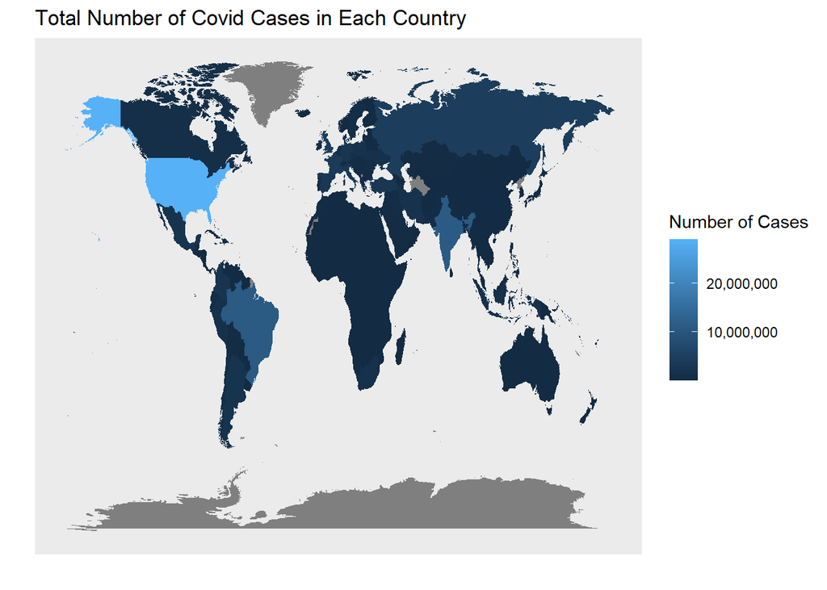

The map illustrates the relationship between Covid-19 cases and location. The number of Covid-19 cases is cumulative from throughout the pandemic and does not reflect the current number of cases. The most pertinent observation in the chart is that the US seems to have the greatest number of total cases, this observation is clear due to the coloring of the US. Brazil and India also appear to have higher case numbers compared to the rest of the world. These observations are based on the color hues of the countries.

**Below is a scatterplot comparing the Government Response Stringency Index of each country with their total reported Covid-19 cases per million people in the population.**

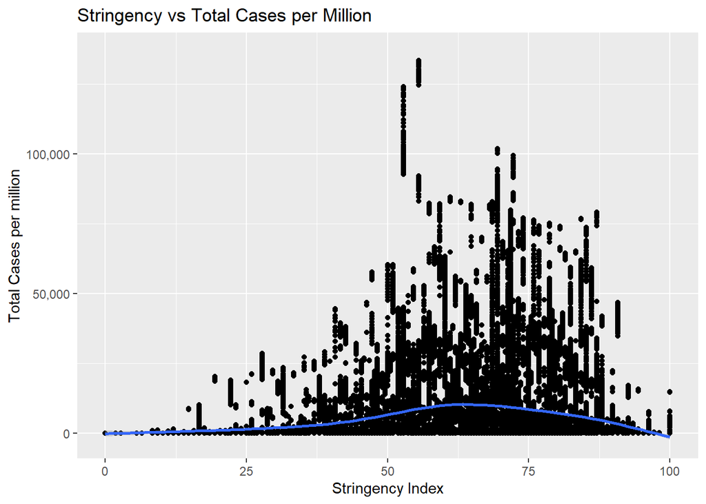

The scatterplot was especially useful in illustrating the relationship between stringency and total cases in each country because of the continuous nature of each variable. The Government Response Stringency Index is a measure based on 9 indicators including school closures, workplace closures, and travel bans. The Index is rescaled to values ranging from 0 to 100, with 100 being the strictest response. It is important to note that each country has multiple data points on the scatterplot to reflect their subsequent change in stringency as the Covid-19 pandemic has unfolded. What’s most interesting about this plot is that it reveals how Covid-19 cases seem to rise even as stringency levels increase in countries. This likely reflects a rise in stringency as a response to worsening public health conditions. However, the rate of cases seems to decrease after a stringency index of approximately 63 is enforced. This logically suggests that countries with a high enough stringency index tend experience fewer total Covid-19 cases.

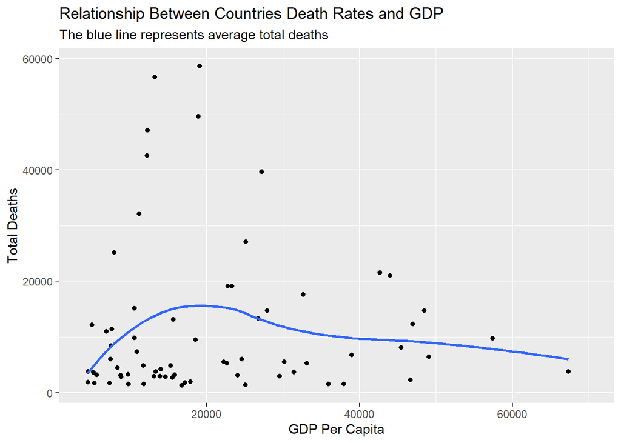